# Replication2

Tian Tong

2025-03-30

## Load the data

```r
uk_data <- read_csv("uk_data.csv")
```

### Clean speeches: preprocessing

```r
uk_data_clean <- uk_data %>%
  filter(!is.na(text), str_trim(text) != "") %>%
  mutate(
    word_count = str_count(text, "\\S+"),
    speech_clean = text %>%
      str_to_lower() %>%
      str_replace_all("[^a-z\\s]", "") %>%
      str_squish()
  ) %>%
  filter(word_count >= 10)
```

```r
# Preview cleaned data
uk_data_clean %>% select(id_speech, text, speech_clean, word_count) %>% head()
```

```
## # A tibble: 6 × 4
##   id_speech text                                         speech_clean word_count
##       <dbl> <chr>                                        <chr>             <int>
## 1         1 Under the provisions of Standing Order No 1… under the p…         26
## 2         2 I beg to move That Mr Michael J Martin do t… i beg to mo…        789
## 3         3 Mr Speaker Elect it is a great pleasure to … mr speaker …        746
## 4         4 On behalf of all my right hon and hon Frien… on behalf o…        847
## 5         5 Mr Speaker Elect may I entirely associate m… mr speaker …        482
## 6         6 Mr Speaker Elect on my behalf and that of m… mr speaker …        341
```

## Extension: Create a domain-specific emotive/neutral dictionary of our own

```r
library(data.table)
library(text2vec)
library(stringr)
library(dplyr)
library(readr)
```

### Prepare the corpus

```r
# Use cleaned speech column
corpus <- uk_data_clean$speech_clean

# Create a text iterator for tokenization
tokens <- itoken(corpus,
                 tokenizer = word_tokenizer,
                 progressbar = TRUE)
```

```r
# Build vocabulary and remove very rare words
vocab <- create_vocabulary(tokens) %>%
  prune_vocabulary(term_count_min = 8)

# Vectorizer
vectorizer <- vocab_vectorizer(vocab)
```

### Train the Word2Vec Model(to highlight this in presentation)

```r
w2v_model <- word2vec::word2vec(
  x = sample(corpus, 100000),  # 100K speeches instead of all
  type = "skip-gram", # other types
  dim = 100,
  window = 5,
  iter = 3,
  min_count = 5,
  threads = 4
)
```

As we could not **easily extract the word vectors** afterward using the CRAN version of `word2vec`, which limits the ability to compute cosine similarity.

```r
library(wordVectors)

# Save the cleaned speeches to a text file
writeLines(corpus, "corpus.txt")
```

```r
train_word2vec(
  train_file = "corpus.txt",
  output_file = "vectors.bin",
  vectors = 100,      # embedding dimension
  threads = 4,
  window = 5,         # context window
  iter = 3,           # number of passes
  min_count = 8,      # ignore rare words
  force = TRUE        # overwrite if file exists
)
```

```
## Starting training using file /Users/tyf981126/Desktop/Replication#2/corpus.txt
## 100K200K300K400K500K600K700K800K900K1000K1100K1200K1300K1400… size: 51095
## Words in train file: 168356789
```

```
## Filename ends with .bin, so reading in binary format
```

```
## Reading a word2vec binary file of 51095 rows and 100 columns
```

[output not shown]

```
## A VectorSpaceModel object of  51095  words and  100  vectors
##              [,1]         [,2]         [,3]         [,4]         [,5]
## </s>  0.004002686  0.004419403 -0.003830261 -0.003278046  0.001366577
## the  -0.062912755 -0.255172074 -0.182681710 -0.064113691  0.170487493
## to    0.140238121 -0.655409396 -0.172222108  0.146436259 -0.175526246
## that -0.161520645 -0.232965186 -0.076012179  0.178989336 -0.170772269
## of    0.193611726 -0.166508079 -0.018571759 -0.052062847  0.124568522
## and   0.288057595 -0.347270131  0.116030209  0.203769460 -0.061512791
## in   -0.045842811 -0.139766261  0.027918130  0.108931564 -0.160648212
## a    -0.359928399  0.063581422 -0.391217053  0.252254516 -0.021944562
## is   -0.070928849  0.034423418  0.071570814 -0.397148848 -0.153979853
## i    -0.168138519 -0.056991074  0.285470545  0.351398349 -0.044804920
##              [,6]
## </s>  0.003021088
## the  -0.101433769
## to   -0.111611634
## that -0.242166370
## of   -0.337608814
## and  -0.284551591
## in   -0.434597343
## a     0.177097276
## is   -0.188684314
## i    -0.442405969
## attr(,".cache")
## <environment: 0x3eff13d88>
```

### Expand the dictionary

```r
model <- read.vectors("vectors.bin")
```

```
## Filename ends with .bin, so reading in binary format
```

```
## Reading a word2vec binary file of 51095 rows and 100 columns
```

[output not shown]

```r
library(readr)
library(dplyr)
library(tidyr)

nrc <- read_delim("NRC-Emotion-Lexicon/NRC-Emotion-Lexicon-Wordlevel-v0.92.txt",
                  delim = "\t", col_names = c("word", "emotion", "value"))
```

### Extract emotive and neutral seed words

```r
# Get emotive words (only keep those with value = 1 in emotion categories)
emotive_emotions <- c("anger", "fear", "joy", "disgust", "sadness", "trust", "surprise", "anticipation")

emotive_seeds <- nrc %>%
  filter(emotion %in% emotive_emotions, value == 1) %>%
  distinct(word) %>%
  pull(word)

# Get sentiment labels (positive/negative only)
sentiment_wide <- nrc %>%
  filter(emotion %in% c("positive", "negative")) %>%
  pivot_wider(names_from = emotion, values_from = value, values_fill = 0)

# Neutral words = words with both pos & neg == 0
neutral_seeds <- sentiment_wide %>%
  filter(positive == 0 & negative == 0) %>%
  pull(word)
```

### Keep only words that exist in model

```r
emotive_seeds <- emotive_seeds[emotive_seeds %in% rownames(model)]
neutral_seeds <- neutral_seeds[neutral_seeds %in% rownames(model)]
```

### Compute cosine similarity scores

```r
cosine_sim <- function(x, y) {
  x <- x / sqrt(sum(x^2))
  y <- y / sqrt(sum(y^2))
  sum(x * y)
}

# Compute average vector for each group
emotive_center <- colMeans(model[emotive_seeds, , drop = FALSE])
neutral_center <- colMeans(model[neutral_seeds, , drop = FALSE])

# Score every word in the model
words <- rownames(model)
scores <- sapply(words, function(w) {
  vec <- model[w, , drop = FALSE]
  cosine_sim(vec, emotive_center) - cosine_sim(vec, neutral_center)
})

# Combine into a dataframe
dictionary <- data.frame(
  word = words,
  score = scores
)
```

### Build emotive and neutral expanded lists

```r
library(dplyr)

top_pct <- 0.025  # Top/bottom 2.5%
n <- nrow(dictionary)
cutoff <- ceiling(n * top_pct)

emotive_expanded <- dictionary %>%
  arrange(desc(score)) %>%
  slice(1:cutoff)

neutral_expanded <- dictionary %>%
  arrange(score) %>%
  slice(1:cutoff)

# Save
write.csv(emotive_expanded, "emotive_expanded.csv", row.names = FALSE)
write.csv(neutral_expanded, "neutral_expanded.csv", row.names = FALSE)
```

## Score each speech using the expanded dictionary

```r
library(tokenizers)

# Tokenize cleaned speech into word lists
speech_tokens <- tokenize_words(uk_data_clean$speech_clean, lowercase = TRUE)
```

```r
str(speech_tokens[[1]])
```

```
##  chr [1:26] "under" "the" "provisions" "of" "standing" "order" "no" "a" "i" ...
```

```r
#test
```

```r
library(stringr)

# Convert dictionary words to sets
emotive_set <- emotive_expanded$word
neutral_set <- neutral_expanded$word

# Score each speech
speech_scores <- sapply(speech_tokens, function(tokens) {
  tokens <- tokens[tokens %in% rownames(model)]
  total <- length(tokens)
  if (total == 0) return(NA)

  n_emotive <- sum(tokens %in% emotive_set)
  n_neutral <- sum(tokens %in% neutral_set)

  score <- (n_emotive - n_neutral) / total
  return(score)
})
```

```r
library(wordVectors)

# Example words
emotive_example <- c("evil", "good", "respect", "appreciate", "commend")
neutral_example <- c("megabits", "infrastructure", "copper", "wires", "superfast", "fibre")

# Filter to keep only words found in the Word2Vec model
emotive_filtered <- emotive_example[emotive_example %in% rownames(model)]
neutral_filtered <- neutral_example[neutral_example %in% rownames(model)]

# Load emotive and neutral word sets from your dictionary
emotive_set <- emotive_expanded$word
neutral_set <- neutral_expanded$word

# Function to score a speech vector based on word matches
score_speech <- function(tokens, emotive_set, neutral_set) {
  tokens <- tokens[tokens %in% rownames(model)]
  total <- length(tokens)
  if (total == 0) return(NA)

  n_emotive <- sum(tokens %in% emotive_set)
  n_neutral <- sum(tokens %in% neutral_set)

  # Unscaled raw score
  score <- (n_emotive - n_neutral) / total
  return(score)
}

# Get scores
emotive_score <- score_speech(emotive_filtered, emotive_set, neutral_set)
neutral_score <- score_speech(neutral_filtered, emotive_set, neutral_set)

# Optional: Rescale like in original article (e.g., ×100 for visibility)
emotive_score_scaled <- round(emotive_score * 100, 2)
neutral_score_scaled <- round(neutral_score * 100, 2)

# Output
cat("Emotive Example Score:", emotive_score_scaled, "\n")
```

```
## Emotive Example Score: 20
```

```r
cat("Neutral Example Score:", neutral_score_scaled, "\n")
```

```
## Neutral Example Score: -16.67
```

Example 1: Evil happens when good people stand by and do nothing. There is evil running through and infiltrating the Labour party, but it is full of good people and they are trying to do something about it. I commend them, appreciate them and have nothing but respect for them.

**Emotive Example Score: 20**

Example 2: When used with old-fashioned copper wires, 10 megabits can become a lot less than that. We need a superfast fibre infrastructure instead of copper wires.

**Neutral Example Score: -16.67**

- This suggests a **low or even negatively emotional tone**, likely due to a higher share of neutral or unrecognized words. This mirrors the original article’s classification of the second quote as “neutral”.

## Main Replication

```r
# Attach scores to dataset
uk_data_clean$emotive_score <- speech_scores
```

```r
colnames(uk_data_clean)
```

```
##  [1] "id_speech"               "id_mp"
##  [3] "period"                  "last_name"
##  [5] "first_name"              "date"
##  [7] "pm_questions"            "queen_debate_day1"
##  [9] "queen_debate_others"     "m_questions"
## [11] "u_questions"             "other_debate"
## [13] "leader"                  "prime_minister"
## [15] "senior_minister"         "shadow"
## [17] "cabinet"                 "chair"
## [19] "government"              "female"
## [21] "age"                     "electoral_cycle"
## [23] "party"                   "linear_trend"
## [25] "words"                   "text"
## [27] "emotive_count"           "neutral_count"
## [29] "emotive_rhetoric"        "emotive_rhetoric_log"
## [31] "emotive_words"           "top_topic"
## [33] "anew_rescaled"           "emotive_rhetoric_liwc"
## [35] "positive_count"          "negative_count"
## [37] "emotive_positive"        "emotive_negative"
## [39] "emotive_count_250_8"     "neutral_count_250_8"
## [41] "emotive_rhetoric_250_8"  "emotive_count_300_10"
## [43] "neutral_count_300_10"    "emotive_rhetoric_300_10"
## [45] "emotive_count_a1"        "neutral_count_a1"
## [47] "emotive_rhetoric_a1"     "emotive_count_a2"
## [49] "neutral_count_a2"        "emotive_rhetoric_a2"
## [51] "word_count"              "speech_clean"
## [53] "emotive_score"
```

### Replication Regression

#### Baseline model:

```r
# Table 3: Column (1)
model_table3_col1 <- lm(
  emotive_score ~ pm_questions + queen_debate_day1 +
    queen_debate_others + m_questions + u_questions,
  data = uk_data_clean
)

summary(model_table3_col1)
```

```
##
## Call:
## lm(formula = emotive_score ~ pm_questions + queen_debate_day1 +
##     queen_debate_others + m_questions + u_questions, data = uk_data_clean)
##
## Residuals:
##       Min        1Q    Median        3Q       Max
## -0.249450 -0.001719 -0.001719  0.000550  0.235844
##
## Coefficients:
##                       Estimate Std. Error t value Pr(>|t|)
## (Intercept)          1.719e-03  1.758e-05  97.766  < 2e-16 ***
## pm_questions         1.548e-03  7.542e-05  20.521  < 2e-16 ***
## queen_debate_day1    1.273e-03  2.636e-04   4.829 1.37e-06 ***
## queen_debate_others  9.252e-04  1.224e-04   7.560 4.04e-14 ***
## m_questions         -2.269e-03  3.108e-05 -72.996  < 2e-16 ***
## u_questions          1.606e-03  7.203e-05  22.294  < 2e-16 ***
## ---
## Signif. codes:  0 '***' 0.001 '**' 0.01 '*' 0.05 '.' 0.1 ' ' 1
##
## Residual standard error: 0.01352 on 956800 degrees of freedom
## Multiple R-squared:  0.007715,   Adjusted R-squared:  0.00771
## F-statistic:  1488 on 5 and 956800 DF,  p-value: < 2.2e-16
```

```r
# Recreate 'time' variable based on date if it doesn't already exist
if (is.null(uk_data_clean$time)) {
  uk_data_clean$time <- NA
  years <- 2001:2019
  for (y in years) {
    uk_data_clean$time[uk_data_clean$date >= as.Date(paste0(y, "-01-01")) &
                         uk_data_clean$date <= as.Date(paste0(y, "-06-30"))] <- paste0(substr(y, 3, 4), "/1")
    uk_data_clean$time[uk_data_clean$date >= as.Date(paste0(y, "-07-01")) &
                         uk_data_clean$date <= as.Date(paste0(y, "-12-31"))] <- paste0(substr(y, 3, 4), "/2")
  }
}
# Now create time_index
uk_data_clean$time_index <- as.numeric(as.factor(uk_data_clean$time))
```

#### Add linear time trend

```r
model_table3_col2 <- lm(
  emotive_score ~ pm_questions + queen_debate_day1 +
    queen_debate_others + m_questions + u_questions + time_index,
  data = uk_data_clean
)

summary(model_table3_col2)
```

```
##
## Call:
## lm(formula = emotive_score ~ pm_questions + queen_debate_day1 +
##     queen_debate_others + m_questions + u_questions + time_index,
##     data = uk_data_clean)
##
## Residuals:
##       Min        1Q    Median        3Q       Max
## -0.249491 -0.002148 -0.001292  0.001047  0.236437
##
## Coefficients:
##                       Estimate Std. Error t value Pr(>|t|)
## (Intercept)          1.070e-03  3.236e-05  33.081  < 2e-16 ***
## pm_questions         1.530e-03  7.540e-05  20.286  < 2e-16 ***
## queen_debate_day1    1.276e-03  2.636e-04   4.843 1.28e-06 ***
## queen_debate_others  9.624e-04  1.224e-04   7.865 3.70e-15 ***
## m_questions         -2.308e-03  3.112e-05 -74.173  < 2e-16 ***
## u_questions          1.304e-03  7.311e-05  17.840  < 2e-16 ***
## time_index           3.168e-05  1.328e-06  23.850  < 2e-16 ***
## ---
## Signif. codes:  0 '***' 0.001 '**' 0.01 '*' 0.05 '.' 0.1 ' ' 1
##
## Residual standard error: 0.01352 on 956799 degrees of freedom
## Multiple R-squared:  0.008305,   Adjusted R-squared:  0.008298
## F-statistic:  1335 on 6 and 956799 DF,  p-value: < 2.2e-16
```

#### Add MP fixed effectes

```r
colnames(uk_data_clean)
```

```
##  [1] "id_speech"               "id_mp"
##  [3] "period"                  "last_name"
##  [5] "first_name"              "date"
##  [7] "pm_questions"            "queen_debate_day1"
##  [9] "queen_debate_others"     "m_questions"
## [11] "u_questions"             "other_debate"
## [13] "leader"                  "prime_minister"
## [15] "senior_minister"         "shadow"
## [17] "cabinet"                 "chair"
## [19] "government"              "female"
## [21] "age"                     "electoral_cycle"
## [23] "party"                   "linear_trend"
## [25] "words"                   "text"
## [27] "emotive_count"           "neutral_count"
## [29] "emotive_rhetoric"        "emotive_rhetoric_log"
## [31] "emotive_words"           "top_topic"
## [33] "anew_rescaled"           "emotive_rhetoric_liwc"
## [35] "positive_count"          "negative_count"
## [37] "emotive_positive"        "emotive_negative"
## [39] "emotive_count_250_8"     "neutral_count_250_8"
## [41] "emotive_rhetoric_250_8"  "emotive_count_300_10"
## [43] "neutral_count_300_10"    "emotive_rhetoric_300_10"
## [45] "emotive_count_a1"        "neutral_count_a1"
## [47] "emotive_rhetoric_a1"     "emotive_count_a2"
## [49] "neutral_count_a2"        "emotive_rhetoric_a2"
## [51] "word_count"              "speech_clean"
## [53] "emotive_score"           "time"
## [55] "time_index"
```

```r
library(fixest)

model_fixest <- feols(
  emotive_score ~ pm_questions + queen_debate_day1 +
    queen_debate_others + m_questions + u_questions | id_mp,
  data = uk_data_clean
)
summary(model_fixest)
```

```
## OLS estimation, Dep. Var.: emotive_score
## Observations: 956,684
## Fixed-effects: id_mp: 1,302
## Standard-errors: Clustered (id_mp)
##                      Estimate Std. Error   t value   Pr(>|t|)
## pm_questions         0.001267   0.000319   3.97321 7.4802e-05 ***
## queen_debate_day1    0.000967   0.000233   4.15580 3.4533e-05 ***
## queen_debate_others  0.000783   0.000127   6.17023 9.0902e-10 ***
## m_questions         -0.001839   0.000097 -18.97552  < 2.2e-16 ***
## u_questions          0.001491   0.000154   9.68549  < 2.2e-16 ***
## ---
## Signif. codes:  0 '***' 0.001 '**' 0.01 '*' 0.05 '.' 0.1 ' ' 1
## RMSE: 0.01329     Adj. R2: 0.040213
##                 Within R2: 0.004805
```

#### Add party, government, prime_minister, cabinet

```r
model_table3_col4 <- lm(
  emotive_score ~ pm_questions + queen_debate_day1 +
    queen_debate_others + m_questions + u_questions +
    party + government + prime_minister + cabinet,
  data = uk_data_clean
)

summary(model_table3_col4)
```

```
##
## Call:
## lm(formula = emotive_score ~ pm_questions + queen_debate_day1 +
##     queen_debate_others + m_questions + u_questions + party +
##     government + prime_minister + cabinet, data = uk_data_clean)
##
## Residuals:
##       Min        1Q    Median        3Q       Max
## -0.249622 -0.002845 -0.000977  0.001311  0.235958
##
## Coefficients:
##                                  Estimate Std. Error t value Pr(>|t|)
## (Intercept)                     3.239e-03  5.025e-05  64.466  < 2e-16 ***
## pm_questions                    1.536e-03  8.703e-05  17.654  < 2e-16 ***
## queen_debate_day1               1.104e-03  2.634e-04   4.190 2.79e-05 ***
## queen_debate_others             8.894e-04  1.222e-04   7.279 3.37e-13 ***
## m_questions                    -2.003e-03  3.182e-05 -62.925  < 2e-16 ***
## u_questions                     1.647e-03  7.261e-05  22.684  < 2e-16 ***
## partyDemocratic Unionist Party  1.390e-03  1.422e-04   9.777  < 2e-16 ***
## partyGreen                      1.379e-03  3.637e-04   3.792  0.00015 ***
## partyLabour                    -2.856e-04  3.570e-05  -8.002 1.22e-15 ***
## partyLiberal Democrats         -2.048e-03  7.156e-05 -28.623  < 2e-16 ***
## partyOthers                     7.434e-04  1.551e-04   4.793 1.64e-06 ***
## partyPlaud Cymru               -1.912e-03  1.927e-04  -9.924  < 2e-16 ***
## partyScottish National Party   -6.366e-04  9.435e-05  -6.747 1.51e-11 ***
## partyUlster Unionist Party      4.995e-04  3.066e-04   1.629  0.10330
## government                     -1.614e-03  4.793e-05 -33.679  < 2e-16 ***
## prime_minister                  6.358e-04  1.010e-04   6.297 3.04e-10 ***
## cabinet                        -6.478e-04  3.425e-05 -18.912  < 2e-16 ***
## ---
## Signif. codes:  0 '***' 0.001 '**' 0.01 '*' 0.05 '.' 0.1 ' ' 1
##
## Residual standard error: 0.0135 on 956789 degrees of freedom
## Multiple R-squared:  0.01149,    Adjusted R-squared:  0.01147
## F-statistic: 694.8 on 16 and 956789 DF,  p-value: < 2.2e-16
```

#### Add weighting by word count

```r
model_table3_col5 <- lm(
  emotive_score ~ pm_questions + queen_debate_day1 +
    queen_debate_others + m_questions + u_questions,
  data = uk_data_clean,
  weights = word_count
)

summary(model_table3_col5)
```

```
##
## Call:
## lm(formula = emotive_score ~ pm_questions + queen_debate_day1 +
##     queen_debate_others + m_questions + u_questions, data = uk_data_clean,
##     weights = word_count)
##
## Weighted Residuals:
##      Min       1Q   Median       3Q      Max
## -2.49597 -0.02016 -0.00929  0.00217  2.26027
##
## Coefficients:
##                       Estimate Std. Error t value Pr(>|t|)
## (Intercept)          1.593e-03  1.174e-05  135.76   <2e-16 ***
## pm_questions         1.962e-03  7.880e-05   24.90   <2e-16 ***
## queen_debate_day1    1.401e-03  1.348e-04   10.39   <2e-16 ***
## queen_debate_others  1.205e-03  6.713e-05   17.96   <2e-16 ***
## m_questions         -1.777e-03  3.333e-05  -53.33   <2e-16 ***
## u_questions          2.106e-03  6.930e-05   30.39   <2e-16 ***
## ---
## Signif. codes:  0 '***' 0.001 '**' 0.01 '*' 0.05 '.' 0.1 ' ' 1
##
## Residual standard error: 0.1375 on 956800 degrees of freedom
## Multiple R-squared:  0.005424,   Adjusted R-squared:  0.005419
## F-statistic:  1044 on 5 and 956800 DF,  p-value: < 2.2e-16
```

### Regression analysis of Fixed Topic Effects

```r
# Table 4: Column (1) — with topic fixed effects
model_table4_col1 <- lm(
  emotive_score ~ pm_questions + queen_debate_day1 +
    queen_debate_others + m_questions + u_questions +
    factor(top_topic),
  data = uk_data_clean
)

summary(model_table4_col1)
```

```
##
## Call:
## lm(formula = emotive_score ~ pm_questions + queen_debate_day1 +
##     queen_debate_others + m_questions + u_questions + factor(top_topic),
##     data = uk_data_clean)
##
## Residuals:
##       Min        1Q    Median        3Q       Max
## -0.251279 -0.003721 -0.001036  0.004767  0.229718
##
## Coefficients:
##                                                Estimate Std. Error  t value
## (Intercept)                                  -4.767e-03  3.558e-05 -133.986
## pm_questions                                  1.674e-03  7.318e-05   22.872
## queen_debate_day1                             1.177e-03  2.555e-04    4.607
## queen_debate_others                           1.320e-03  1.186e-04   11.125
## m_questions                                  -1.659e-03  3.058e-05  -54.262
## u_questions                                   1.299e-03  6.985e-05   18.593
## factor(top_topic)external relations           7.705e-03  5.185e-05  148.610
## factor(top_topic)fabric of society            1.200e-02  5.075e-05  236.508
## factor(top_topic)freedom and democracy        8.489e-03  5.245e-05  161.829
## factor(top_topic)no topic                     5.988e-03  5.011e-04   11.951
## factor(top_topic)political system             6.514e-03  4.333e-05  150.339
## factor(top_topic)social groups                5.796e-03  7.221e-05   80.269
## factor(top_topic)welfare and quality of life  5.803e-03  4.450e-05  130.414
##                                              Pr(>|t|)
## (Intercept)                                   < 2e-16 ***
## pm_questions                                  < 2e-16 ***
## queen_debate_day1                            4.09e-06 ***
## queen_debate_others                           < 2e-16 ***
## m_questions                                   < 2e-16 ***
## u_questions                                   < 2e-16 ***
## factor(top_topic)external relations           < 2e-16 ***
## factor(top_topic)fabric of society            < 2e-16 ***
## factor(top_topic)freedom and democracy        < 2e-16 ***
## factor(top_topic)no topic                     < 2e-16 ***
## factor(top_topic)political system             < 2e-16 ***
## factor(top_topic)social groups                < 2e-16 ***
## factor(top_topic)welfare and quality of life  < 2e-16 ***
## ---
## Signif. codes:  0 '***' 0.001 '**' 0.01 '*' 0.05 '.' 0.1 ' ' 1
##
## Residual standard error: 0.0131 on 956793 degrees of freedom
## Multiple R-squared:  0.06838,    Adjusted R-squared:  0.06837
## F-statistic:  5852 on 12 and 956793 DF,  p-value: < 2.2e-16
```

#### Add linear time trend

```r
# Model with time trend + topic fixed effects
model_table4_col2 <- lm(
  emotive_score ~ pm_questions + queen_debate_day1 +
    queen_debate_others + m_questions + u_questions +
    time_index +  factor(top_topic),
  data = uk_data_clean
)

summary(model_table4_col2)
```

```
##
## Call:
## lm(formula = emotive_score ~ pm_questions + queen_debate_day1 +
##     queen_debate_others + m_questions + u_questions + time_index +
##     factor(top_topic), data = uk_data_clean)
##
## Residuals:
##       Min        1Q    Median        3Q       Max
## -0.251228 -0.003546 -0.001051  0.004435  0.230532
##
## Coefficients:
##                                                Estimate Std. Error  t value
## (Intercept)                                  -5.730e-03  4.514e-05 -126.946
## pm_questions                                  1.653e-03  7.314e-05   22.599
## queen_debate_day1                             1.178e-03  2.553e-04    4.613
## queen_debate_others                           1.377e-03  1.186e-04   11.615
## m_questions                                  -1.706e-03  3.059e-05  -55.759
## u_questions                                   8.754e-04  7.087e-05   12.352
## time_index                                    4.464e-05  1.289e-06   34.627
## factor(top_topic)external relations           7.726e-03  5.182e-05  149.093
## factor(top_topic)fabric of society            1.206e-02  5.075e-05  237.722
## factor(top_topic)freedom and democracy        8.562e-03  5.246e-05  163.200
## factor(top_topic)no topic                     6.114e-03  5.008e-04   12.209
## factor(top_topic)political system             6.592e-03  4.336e-05  152.033
## factor(top_topic)social groups                5.831e-03  7.217e-05   80.794
## factor(top_topic)welfare and quality of life  5.844e-03  4.448e-05  131.368
##                                              Pr(>|t|)
## (Intercept)                                   < 2e-16 ***
## pm_questions                                  < 2e-16 ***
## queen_debate_day1                            3.97e-06 ***
## queen_debate_others                           < 2e-16 ***
## m_questions                                   < 2e-16 ***
## u_questions                                   < 2e-16 ***
## time_index                                    < 2e-16 ***
## factor(top_topic)external relations           < 2e-16 ***
## factor(top_topic)fabric of society            < 2e-16 ***
## factor(top_topic)freedom and democracy        < 2e-16 ***
## factor(top_topic)no topic                     < 2e-16 ***
## factor(top_topic)political system             < 2e-16 ***
## factor(top_topic)social groups                < 2e-16 ***
## factor(top_topic)welfare and quality of life  < 2e-16 ***
## ---
## Signif. codes:  0 '***' 0.001 '**' 0.01 '*' 0.05 '.' 0.1 ' ' 1
##
## Residual standard error: 0.0131 on 956792 degrees of freedom
## Multiple R-squared:  0.06954,    Adjusted R-squared:  0.06953
## F-statistic:  5501 on 13 and 956792 DF,  p-value: < 2.2e-16
```

#### Add MP fixed effect

```r
model_table4_col3 <- feols(
  emotive_score ~ pm_questions + queen_debate_day1 +
    queen_debate_others + m_questions + u_questions | id_mp + factor(top_topic),
  data = uk_data_clean
)
```

```
## NOTE: 122 observations removed because of NA values (Fixed-effects: 122).
```

```r
summary(model_table4_col3)
```

```
## OLS estimation, Dep. Var.: emotive_score
## Observations: 956,684
## Fixed-effects: id_mp: 1,302,  factor(top_topic): 8
## Standard-errors: Clustered (id_mp)
##                      Estimate Std. Error   t value   Pr(>|t|)
## pm_questions         0.001663   0.000210   7.92665 4.8068e-15 ***
## queen_debate_day1    0.001000   0.000228   4.38418 1.2581e-05 ***
## queen_debate_others  0.001056   0.000114   9.29223  < 2.2e-16 ***
## m_questions         -0.001375   0.000077 -17.78272  < 2.2e-16 ***
## u_questions          0.001160   0.000136   8.54443  < 2.2e-16 ***
## ---
## Signif. codes:  0 '***' 0.001 '**' 0.01 '*' 0.05 '.' 0.1 ' ' 1
## RMSE: 0.01294     Adj. R2: 0.090019
##                 Within R2: 0.003244
```

#### Add party

```r
model_table4_col4 <- lm(
  emotive_score ~ pm_questions + queen_debate_day1 +
    queen_debate_others + m_questions + u_questions +
    party + government + prime_minister + cabinet + factor(top_topic),
  data = uk_data_clean
)

summary(model_table4_col4)
```

```
##
## Call:
## lm(formula = emotive_score ~ pm_questions + queen_debate_day1 +
##     queen_debate_others + m_questions + u_questions + party +
##     government + prime_minister + cabinet + factor(top_topic),
##     data = uk_data_clean)
##
## Residuals:
##       Min        1Q    Median        3Q       Max
## -0.251323 -0.003644 -0.000914  0.004354  0.229987
##
## Coefficients:
##                                                Estimate Std. Error t value
## (Intercept)                                  -2.824e-03  5.710e-05 -49.452
## pm_questions                                  1.841e-03  8.442e-05  21.805
## queen_debate_day1                             1.050e-03  2.551e-04   4.115
## queen_debate_others                           1.271e-03  1.184e-04  10.739
## m_questions                                  -1.383e-03  3.129e-05 -44.195
## u_questions                                   1.284e-03  7.039e-05  18.237
## partyDemocratic Unionist Party                1.103e-04  1.379e-04   0.800
## partyGreen                                    1.532e-03  3.523e-04   4.347
## partyLabour                                  -5.031e-04  3.460e-05 -14.541
## partyLiberal Democrats                       -2.248e-03  6.933e-05 -32.431
## partyOthers                                  -8.926e-05  1.503e-04  -0.594
## partyPlaud Cymru                             -2.433e-03  1.867e-04 -13.031
## partyScottish National Party                 -9.602e-04  9.144e-05 -10.501
## partyUlster Unionist Party                   -1.498e-03  2.971e-04  -5.040
## government                                   -2.054e-03  4.647e-05 -44.200
## prime_minister                                2.759e-04  9.815e-05   2.811
## cabinet                                      -6.166e-04  3.319e-05 -18.579
## factor(top_topic)external relations           7.778e-03  5.191e-05 149.857
## factor(top_topic)fabric of society            1.207e-02  5.071e-05 238.023
## factor(top_topic)freedom and democracy        8.522e-03  5.236e-05 162.745
## factor(top_topic)no topic                     5.961e-03  4.999e-04  11.923
## factor(top_topic)political system             6.527e-03  4.325e-05 150.933
## factor(top_topic)social groups                5.729e-03  7.209e-05  79.474
## factor(top_topic)welfare and quality of life  5.791e-03  4.443e-05 130.343
##                                              Pr(>|t|)
## (Intercept)                                   < 2e-16 ***
## pm_questions                                  < 2e-16 ***
```

[output cut: 13 more lines]

```
## prime_minister                                0.00494 **
## cabinet                                       < 2e-16 ***
## factor(top_topic)external relations           < 2e-16 ***
## factor(top_topic)fabric of society            < 2e-16 ***
## factor(top_topic)freedom and democracy        < 2e-16 ***
## factor(top_topic)no topic                     < 2e-16 ***
## factor(top_topic)political system             < 2e-16 ***
## factor(top_topic)social groups                < 2e-16 ***
## factor(top_topic)welfare and quality of life  < 2e-16 ***
## ---
## Signif. codes:  0 '***' 0.001 '**' 0.01 '*' 0.05 '.' 0.1 ' ' 1
##
## Residual standard error: 0.01307 on 956782 degrees of freedom
## Multiple R-squared:  0.07269,    Adjusted R-squared:  0.07267
## F-statistic:  3261 on 23 and 956782 DF,  p-value: < 2.2e-16
```

#### Add weighting by word count

```r
model_table4_col5 <- lm(
  emotive_score ~ pm_questions + queen_debate_day1 +
    queen_debate_others + m_questions + u_questions + factor(top_topic),
  data = uk_data_clean,
  weights = word_count
)

summary(model_table4_col5)
```

```
##
## Call:
## lm(formula = emotive_score ~ pm_questions + queen_debate_day1 +
##     queen_debate_others + m_questions + u_questions + factor(top_topic),
##     data = uk_data_clean, weights = word_count)
##
## Weighted Residuals:
##      Min       1Q   Median       3Q      Max
## -2.20833 -0.03537 -0.00770  0.04192  2.07760
##
## Coefficients:
##                                                Estimate Std. Error  t value
## (Intercept)                                  -4.939e-03  2.645e-05 -186.715
## pm_questions                                  2.010e-03  7.455e-05   26.963
## queen_debate_day1                             1.155e-03  1.275e-04    9.061
## queen_debate_others                           1.401e-03  6.350e-05   22.068
## m_questions                                  -1.242e-03  3.171e-05  -39.187
## u_questions                                   1.626e-03  6.555e-05   24.803
## factor(top_topic)external relations           8.260e-03  3.869e-05  213.495
## factor(top_topic)fabric of society            1.213e-02  3.836e-05  316.101
## factor(top_topic)freedom and democracy        8.646e-03  3.776e-05  228.961
## factor(top_topic)no topic                     6.121e-03  6.489e-04    9.433
## factor(top_topic)political system             6.117e-03  3.304e-05  185.151
## factor(top_topic)social groups                5.303e-03  5.415e-05   97.927
## factor(top_topic)welfare and quality of life  5.941e-03  3.457e-05  171.861
##                                              Pr(>|t|)
## (Intercept)                                    <2e-16 ***
## pm_questions                                   <2e-16 ***
## queen_debate_day1                              <2e-16 ***
## queen_debate_others                            <2e-16 ***
## m_questions                                    <2e-16 ***
## u_questions                                    <2e-16 ***
## factor(top_topic)external relations            <2e-16 ***
## factor(top_topic)fabric of society             <2e-16 ***
## factor(top_topic)freedom and democracy         <2e-16 ***
## factor(top_topic)no topic                      <2e-16 ***
## factor(top_topic)political system              <2e-16 ***
## factor(top_topic)social groups                 <2e-16 ***
## factor(top_topic)welfare and quality of life   <2e-16 ***
## ---
## Signif. codes:  0 '***' 0.001 '**' 0.01 '*' 0.05 '.' 0.1 ' ' 1
##
## Residual standard error: 0.13 on 956793 degrees of freedom
## Multiple R-squared:  0.1112, Adjusted R-squared:  0.1112
## F-statistic:  9975 on 12 and 956793 DF,  p-value: < 2.2e-16
```

Full model analysis with variables:

- Prime Minister’s Questions
- Day 1 of Queen’s Speech Debate
- Other days of Queen’s Speech Debate
- Ministerial Questions
- Urgent Questions
- Other Parliamentary Debate types

```r
model1 <- lm(emotive_score ~ government + party + prime_minister + cabinet +
               pm_questions + queen_debate_day1 + queen_debate_others +
               m_questions + u_questions + other_debate +
               top_topic,
             data = uk_data_clean)

summary(model1)
```

```
##
## Call:
## lm(formula = emotive_score ~ government + party + prime_minister +
##     cabinet + pm_questions + queen_debate_day1 + queen_debate_others +
##     m_questions + u_questions + other_debate + top_topic, data = uk_data_clean)
##
## Residuals:
##       Min        1Q    Median        3Q       Max
## -0.251323 -0.003644 -0.000914  0.004354  0.229987
##
## Coefficients: (1 not defined because of singularities)
##                                        Estimate Std. Error t value Pr(>|t|)
## (Intercept)                          -2.824e-03  5.710e-05 -49.452  < 2e-16 ***
## government                           -2.054e-03  4.647e-05 -44.200  < 2e-16 ***
## partyDemocratic Unionist Party        1.103e-04  1.379e-04   0.800  0.42374
## partyGreen                            1.532e-03  3.523e-04   4.347 1.38e-05 ***
## partyLabour                          -5.031e-04  3.460e-05 -14.541  < 2e-16 ***
## partyLiberal Democrats               -2.248e-03  6.933e-05 -32.431  < 2e-16 ***
## partyOthers                          -8.926e-05  1.503e-04  -0.594  0.55251
## partyPlaud Cymru                     -2.433e-03  1.867e-04 -13.031  < 2e-16 ***
## partyScottish National Party         -9.602e-04  9.144e-05 -10.501  < 2e-16 ***
## partyUlster Unionist Party           -1.498e-03  2.971e-04  -5.040 4.65e-07 ***
## prime_minister                        2.759e-04  9.815e-05   2.811  0.00494 **
## cabinet                              -6.166e-04  3.319e-05 -18.579  < 2e-16 ***
## pm_questions                          1.841e-03  8.442e-05  21.805  < 2e-16 ***
## queen_debate_day1                     1.050e-03  2.551e-04   4.115 3.88e-05 ***
## queen_debate_others                   1.271e-03  1.184e-04  10.739  < 2e-16 ***
## m_questions                          -1.383e-03  3.129e-05 -44.195  < 2e-16 ***
## u_questions                           1.284e-03  7.039e-05  18.237  < 2e-16 ***
## other_debate                                 NA         NA      NA       NA
## top_topicexternal relations           7.778e-03  5.191e-05 149.857  < 2e-16 ***
## top_topicfabric of society            1.207e-02  5.071e-05 238.023  < 2e-16 ***
## top_topicfreedom and democracy        8.522e-03  5.236e-05 162.745  < 2e-16 ***
## top_topicno topic                     5.961e-03  4.999e-04  11.923  < 2e-16 ***
## top_topicpolitical system             6.527e-03  4.325e-05 150.933  < 2e-16 ***
## top_topicsocial groups                5.729e-03  7.209e-05  79.474  < 2e-16 ***
## top_topicwelfare and quality of life  5.791e-03  4.443e-05 130.343  < 2e-16 ***
## ---
## Signif. codes:  0 '***' 0.001 '**' 0.01 '*' 0.05 '.' 0.1 ' ' 1
##
## Residual standard error: 0.01307 on 956782 degrees of freedom
## Multiple R-squared:  0.07269,    Adjusted R-squared:  0.07267
## F-statistic:  3261 on 23 and 956782 DF,  p-value: < 2.2e-16
```

Exntension plot

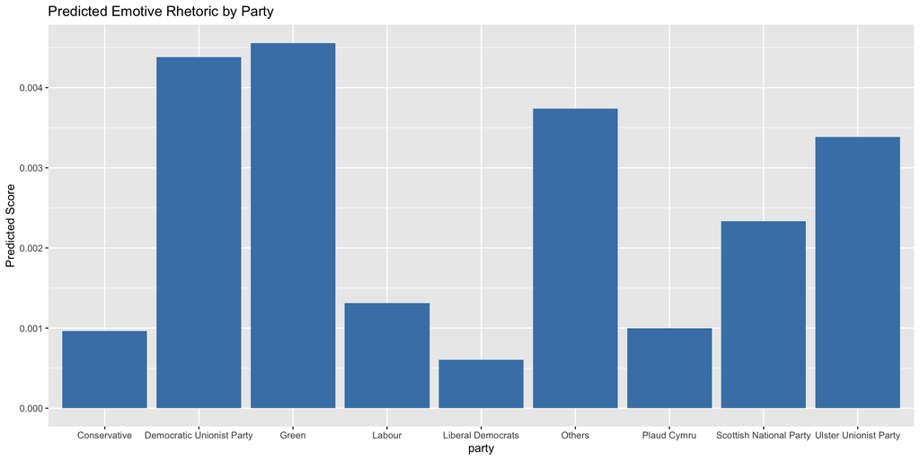

```r
library(ggplot2)
uk_data_clean$pred <- predict(model1)

ggplot(uk_data_clean, aes(x = party, y = pred)) +
  stat_summary(fun = mean, geom = "col", fill = "steelblue") +
  labs(title = "Predicted Emotive Rhetoric by Party", y = "Predicted Score")
```

Use similar code to generate Fig.2 in original paper

Plot

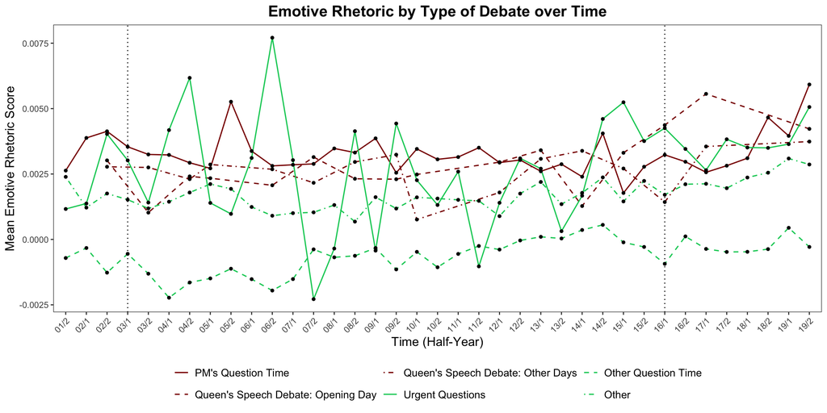

```r
library(ggplot2)
library(dplyr)
library(stringr)
library(plyr)
# STEP 1: Create the time variable
uk_data_clean$time <- NA
uk_data_clean$date <- as.Date(uk_data_clean$date)  # ensure date format

years <- 2001:2019
for (y in years) {
  uk_data_clean$time[uk_data_clean$date >= as.Date(paste0(y, "-01-01")) &
                      uk_data_clean$date <= as.Date(paste0(y, "-06-30"))] <- paste0(substr(y, 3, 4), "/1")
  uk_data_clean$time[uk_data_clean$date >= as.Date(paste0(y, "-07-01")) &
                      uk_data_clean$date <= as.Date(paste0(y, "-12-31"))] <- paste0(substr(y, 3, 4), "/2")
}

# STEP 2: Create the stage variable
uk_data_clean$stage <- 0
uk_data_clean$stage[uk_data_clean$m_questions == 1] <- 1
uk_data_clean$stage[uk_data_clean$u_questions == 1] <- 2
uk_data_clean$stage[uk_data_clean$queen_debate_others == 1] <- 3
uk_data_clean$stage[uk_data_clean$queen_debate_day1 == 1] <- 4
uk_data_clean$stage[uk_data_clean$pm_questions == 1] <- 5

# STEP 3: Compute means by time and stage
calc_mean <- function(x){
  mean_emotive <- mean(x$emotive_score, na.rm = TRUE)
  cbind(mean_emotive)
}

result_clean <- ddply(uk_data_clean, c("time", "stage"), calc_mean)
colnames(result_clean) <- c("time", "stage", "emotive_rhetoric")

# STEP 4: Add debate type labels
result_clean$type <- NA
result_clean$type[result_clean$stage == 5] <- "PM's Question Time"
result_clean$type[result_clean$stage == 4] <- "Queen's Speech Debate: Opening Day"
result_clean$type[result_clean$stage == 3] <- "Queen's Speech Debate: Other Days"
result_clean$type[result_clean$stage == 2] <- "Urgent Questions"
result_clean$type[result_clean$stage == 1] <- "Other Question Time"
result_clean$type[result_clean$stage == 0] <- "Other"

result_clean$type <- factor(result_clean$type, levels = c("PM's Question Time",
                                                          "Queen's Speech Debate: Opening Day",
                                                          "Queen's Speech Debate: Other Days",
                                                          "Urgent Questions",
                                                          "Other Question Time",
                                                          "Other"))

# Optional: drop 01/1 to match original article
result_clean <- subset(result_clean, time != "01/1")

# STEP 5: Plot
fig2_clean <- ggplot(result_clean, aes(x = time, y = emotive_rhetoric, group = type)) +
  geom_line(aes(color = type, linetype = type), linewidth = 0.6) +
  geom_point(color = "black", size = 1.2) +
  xlab("Time (Half-Year)") +
  ylab("Mean Emotive Rhetoric Score") +
  ggtitle("Emotive Rhetoric by Type of Debate over Time") +
  geom_vline(xintercept = 4, linetype = "dotted") +
  geom_vline(xintercept = 30, linetype = "dotted") +
  scale_color_manual(values = c("darkred", "darkred", "darkred",
                                "springgreen3", "springgreen3", "springgreen3")) +
  scale_linetype_manual(values = c("solid", "dashed", "dotdash",
                                   "solid", "dashed", "dotdash")) +
  theme_bw() +
  theme(
    panel.grid.major = element_blank(),
    panel.grid.minor = element_blank(),
    legend.title = element_blank(),
    axis.text.x = element_text(angle = 45, hjust = 1, size = 9),
    axis.text.y = element_text(size = 9),
    axis.title = element_text(size = 13),
    plot.title = element_text(size = 16, face = "bold", hjust = 0.5),
    legend.text = element_text(size = 11),
    legend.position = "bottom"
  )

print(fig2_clean)
```

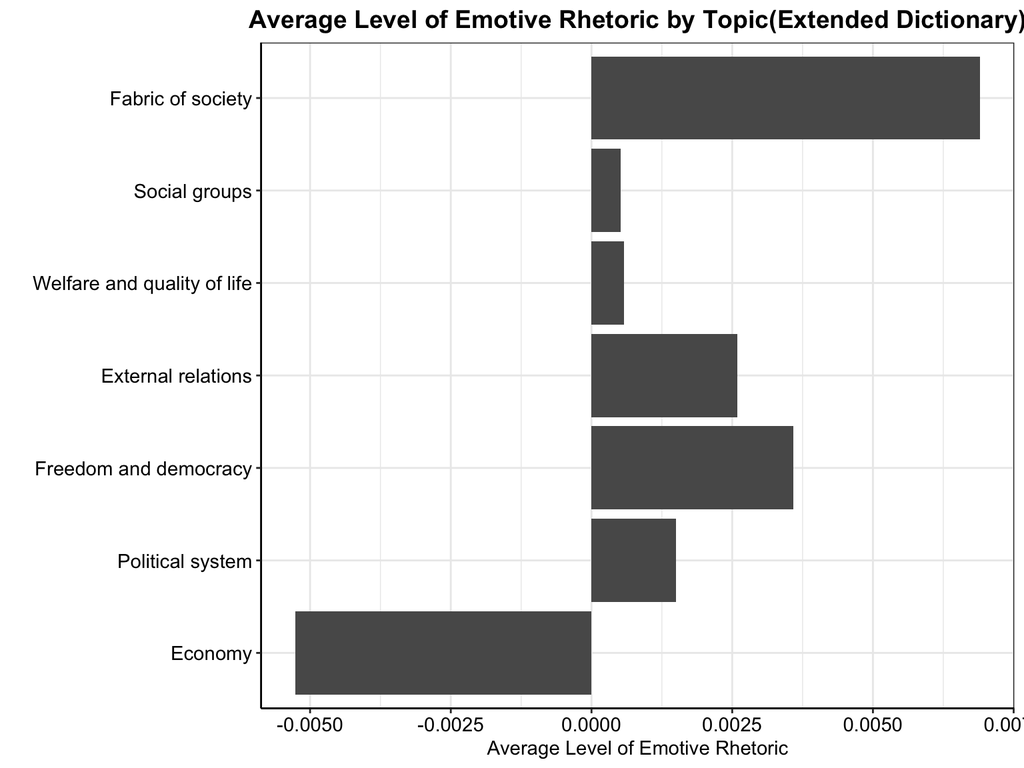

```r
library(dplyr)
library(ggplot2)
library(plyr)  # to match original code

# Standardize topic labels
uk_data_clean$top_topic <- as.character(uk_data_clean$top_topic)
uk_data_clean$top_topic[uk_data_clean$top_topic == "fabric of society"] <- "Fabric of society"
uk_data_clean$top_topic[uk_data_clean$top_topic == "social groups"] <- "Social groups"
uk_data_clean$top_topic[uk_data_clean$top_topic == "welfare and quality of life"] <- "Welfare and quality of life"
uk_data_clean$top_topic[uk_data_clean$top_topic == "external relations"] <- "External relations"
uk_data_clean$top_topic[uk_data_clean$top_topic == "freedom and democracy"] <- "Freedom and democracy"
uk_data_clean$top_topic[uk_data_clean$top_topic == "political system"] <- "Political system"
uk_data_clean$top_topic[uk_data_clean$top_topic == "economy"] <- "Economy"
uk_data_clean$top_topic[uk_data_clean$top_topic == "no topic"] <- "No topic"

# Filter out "No topic"
filtered_data <- subset(uk_data_clean, top_topic != "No topic")

# Calculate mean emotive rhetoric per topic
ac <- function(x) {
  m <- mean(x$emotive_score, na.rm = TRUE)
  out <- m
}

result <- ddply(filtered_data, c("top_topic"), ac)
colnames(result) <- c("top_topic", "emotive_rhetoric")

# Set factor levels for ordered plotting
result$top_topic <- factor(result$top_topic, levels = c(
  "Economy", "Political system", "Freedom and democracy",
  "External relations", "Welfare and quality of life",
  "Social groups", "Fabric of society"
))

# Plot Figure 4
ggplot(data = result, aes(x = top_topic, y = emotive_rhetoric)) +
  geom_bar(stat = "identity") +
  coord_flip() +
  ylab("Average Level of Emotive Rhetoric") +
  xlab("") +
  ggtitle("Average Level of Emotive Rhetoric by Topic(Extended Dictionary)") +
  theme_bw() +
  theme(
    axis.text.x = element_text(colour = "black", size = 11),
    axis.text.y = element_text(colour = "black", size = 11),
    axis.line = element_line(color = "black"),
    plot.title = element_text(size = 14, face = "bold", hjust = 0.5)
  )
```

## Full replication workflow using provided dictionary

```r
emotive_dict <- read.csv("emotive_uk.csv", stringsAsFactors = FALSE)
neutral_dict <- read.csv("neutral_uk.csv", stringsAsFactors = FALSE)

emotive_words <- tolower(emotive_dict$word)
neutral_words <- tolower(neutral_dict$word)
```

```r
library(tokenizers)

# Tokenize each speech
speech_tokens_original <- tokenize_words(uk_data_clean$speech_clean)

# Score each speech
speech_scores_original <- sapply(speech_tokens_original, function(tokens) {
  total <- length(tokens)
  if (total == 0) return(NA)

  n_emotive <- sum(tokens %in% emotive_words)
  n_neutral <- sum(tokens %in% neutral_words)

  score <- (n_emotive - n_neutral) / total
  return(score)
})
```

Create a new dataset for original dictionaries

```r
# Create a separate dataset for the original replication
uk_data_original <- uk_data_clean %>%
  select(id_speech, text, speech_clean, date, top_topic, everything()) %>%
  mutate(emotive_rhetoric = speech_scores_original)
```

### Regression

```r
model_original <- lm(emotive_rhetoric ~
                       government +
                       party +
                       prime_minister +
                       cabinet +
                       pm_questions +
                       queen_debate_day1 +
                       queen_debate_others +
                       m_questions +
                       u_questions +
                       other_debate +
                       top_topic,
                     data = uk_data_original)

summary(model_original)
```

```
##
## Call:
## lm(formula = emotive_rhetoric ~ government + party + prime_minister +
##     cabinet + pm_questions + queen_debate_day1 + queen_debate_others +
##     m_questions + u_questions + other_debate + top_topic, data = uk_data_original)
##
## Residuals:
##      Min       1Q   Median       3Q      Max
## -0.39634 -0.02479 -0.00061  0.02444  0.36463
##
## Coefficients: (1 not defined because of singularities)
##                                        Estimate Std. Error t value Pr(>|t|)
## (Intercept)                          -0.0081009  0.0001880 -43.097  < 2e-16 ***
## government                           -0.0008800  0.0001530  -5.753 8.78e-09 ***
## partyDemocratic Unionist Party        0.0067082  0.0004539  14.781  < 2e-16 ***
## partyGreen                            0.0004543  0.0011598   0.392  0.69526
## partyLabour                          -0.0008008  0.0001139  -7.031 2.06e-12 ***
## partyLiberal Democrats               -0.0047427  0.0002282 -20.780  < 2e-16 ***
## partyOthers                           0.0027599  0.0004947   5.579 2.42e-08 ***
## partyPlaud Cymru                     -0.0105897  0.0006145 -17.232  < 2e-16 ***
## partyScottish National Party         -0.0020770  0.0003010  -6.900 5.19e-12 ***
## partyUlster Unionist Party            0.0028556  0.0009782   2.919  0.00351 **
## prime_minister                        0.0061942  0.0003231  19.170  < 2e-16 ***
## cabinet                              -0.0008149  0.0001092  -7.459 8.74e-14 ***
## pm_questions                          0.0076391  0.0002779  27.488  < 2e-16 ***
## queen_debate_day1                     0.0106516  0.0008399  12.682  < 2e-16 ***
## queen_debate_others                   0.0030399  0.0003898   7.799 6.23e-15 ***
## m_questions                          -0.0016514  0.0001030 -16.032  < 2e-16 ***
## u_questions                           0.0018610  0.0002317   8.031 9.66e-16 ***
## other_debate                                 NA         NA      NA       NA
## top_topicExternal relations           0.0137413  0.0001709  80.418  < 2e-16 ***
## top_topicFabric of society            0.0297783  0.0001669 178.374  < 2e-16 ***
## top_topicFreedom and democracy        0.0114736  0.0001724  66.561  < 2e-16 ***
## top_topicNo topic                    -0.0147513  0.0016458  -8.963  < 2e-16 ***
## top_topicPolitical system             0.0069738  0.0001424  48.984  < 2e-16 ***
## top_topicSocial groups                0.0240198  0.0002373 101.217  < 2e-16 ***
## top_topicWelfare and quality of life  0.0215159  0.0001463 147.099  < 2e-16 ***
## ---
## Signif. codes:  0 '***' 0.001 '**' 0.01 '*' 0.05 '.' 0.1 ' ' 1
##
## Residual standard error: 0.04304 on 956782 degrees of freedom
## Multiple R-squared:  0.05159,    Adjusted R-squared:  0.05156
## F-statistic:  2263 on 23 and 956782 DF,  p-value: < 2.2e-16
```

**New model fits slightly better**, even though effect sizes are smaller.

### Fig.2 Replication(provided code)

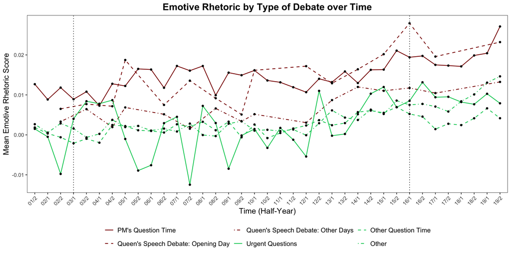

```r
library(ggplot2)
library(dplyr)
library(stringr)
library(plyr)

# STEP 1: Create the time variable
uk_data_original$time <- NA
uk_data_original$date <- as.Date(uk_data_original$date)  # make sure it's in Date format

# Generate half-year time codes
years <- 2001:2019
half_years <- c("01", "07")
time_labels <- unlist(lapply(years, function(y) paste0(substr(y, 3, 4), "/", c(1,2))))

for (i in seq_along(years)) {
  y <- years[i]
  uk_data_original$time[uk_data_original$date >= as.Date(paste0(y, "-01-01")) &
                         uk_data_original$date <= as.Date(paste0(y, "-06-30"))] <- paste0(substr(y, 3, 4), "/1")
  uk_data_original$time[uk_data_original$date >= as.Date(paste0(y, "-07-01")) &
                         uk_data_original$date <= as.Date(paste0(y, "-12-31"))] <- paste0(substr(y, 3, 4), "/2")
}

# STEP 2: Create the stage variable
uk_data_original$stage <- 0
uk_data_original$stage[uk_data_original$m_questions == 1] <- 1
uk_data_original$stage[uk_data_original$u_questions == 1] <- 2
uk_data_original$stage[uk_data_original$queen_debate_others == 1] <- 3
uk_data_original$stage[uk_data_original$queen_debate_day1 == 1] <- 4
uk_data_original$stage[uk_data_original$pm_questions == 1] <- 5

# STEP 3: Compute means by time and stage
calc_mean <- function(x){
  mean_emotive <- mean(x$emotive_rhetoric, na.rm = TRUE)
  cbind(mean_emotive)
}

result <- ddply(uk_data_original, c("time", "stage"), calc_mean)
colnames(result) <- c("time", "stage", "emotive_rhetoric")

# STEP 4: Add debate type labels
result$type <- NA
result$type[result$stage == 5] <- "PM's Question Time"
result$type[result$stage == 4] <- "Queen's Speech Debate: Opening Day"
result$type[result$stage == 3] <- "Queen's Speech Debate: Other Days"
result$type[result$stage == 2] <- "Urgent Questions"
result$type[result$stage == 1] <- "Other Question Time"
result$type[result$stage == 0] <- "Other"

# Factor for plotting order
result$type <- factor(result$type, levels = c("PM's Question Time",
                                              "Queen's Speech Debate: Opening Day",
                                              "Queen's Speech Debate: Other Days",
                                              "Urgent Questions",
                                              "Other Question Time",
                                              "Other"))

# Drop first time bin (optional to match original)
result <- subset(result, time != "01/1")

# STEP 5: Plot
ggplot(result, aes(x = time, y = emotive_rhetoric, group = type)) +
  geom_line(aes(color = type, linetype = type), linewidth = 0.6) +
  geom_point(color = "black", size = 1.2) +  # smaller black dots
  xlab("Time (Half-Year)") +
  ylab("Mean Emotive Rhetoric Score") +
  ggtitle("Emotive Rhetoric by Type of Debate over Time") +
  geom_vline(xintercept = 4, linetype = "dotted") +
  geom_vline(xintercept = 30, linetype = "dotted") +
  scale_color_manual(values = c("darkred", "darkred", "darkred", "springgreen3", "springgreen3", "springgreen3")) +
  scale_linetype_manual(values = c("solid", "dashed", "dotdash", "solid", "dashed", "dotdash")) +
  theme_bw() +
  theme(
    panel.grid.major = element_blank(),
    panel.grid.minor = element_blank(),
    legend.title = element_blank(),
    axis.text.x = element_text(angle = 45, hjust = 1, size = 9),
    axis.text.y = element_text(size = 9),
    axis.title = element_text(size = 13),
    plot.title = element_text(size = 16, face = "bold", hjust = 0.5),
    legend.text = element_text(size = 11),
    legend.position = "bottom"
  )
```

## Topic Modeling

The original paper’s topic modeling approach here is: each topic was manually classified into one of seven topics: economy/political system/freedom and democracy/external relations/welfare and quality of life/social groups/fabric of society.(already pre-classified)

These labels were used as features in regression models to predict emotive rhetoric scores. This allowed them to **control for topic variation** when assessing how much emotive rhetoric varies by debate type (e.g., PMQs vs. other debates). The classification itself was done outside of LDA — it was either **human-coded or derived from prior work** with a labeled dataset

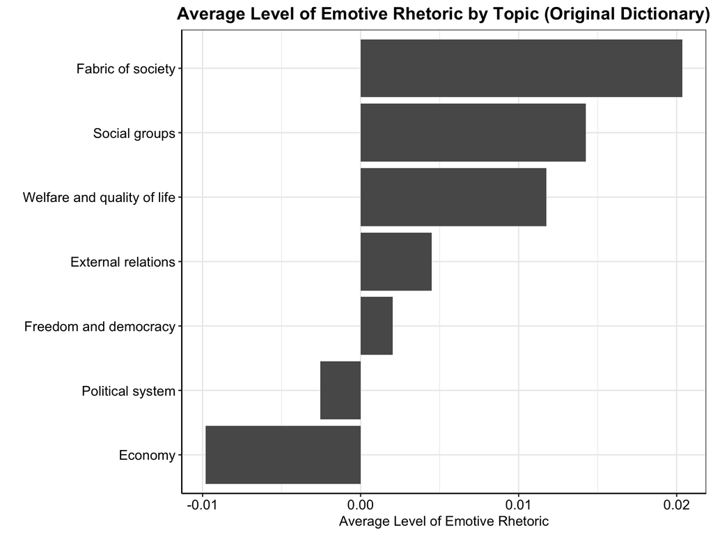

```r
library(dplyr)
library(ggplot2)
library(plyr)  # to match original code

# Standardize topic labels
uk_data_original$top_topic <- as.character(uk_data_original$top_topic)
uk_data_original$top_topic[uk_data_original$top_topic == "fabric of society"] <- "Fabric of society"
uk_data_original$top_topic[uk_data_original$top_topic == "social groups"] <- "Social groups"
uk_data_original$top_topic[uk_data_original$top_topic == "welfare and quality of life"] <- "Welfare and quality of life"
uk_data_original$top_topic[uk_data_original$top_topic == "external relations"] <- "External relations"
uk_data_original$top_topic[uk_data_original$top_topic == "freedom and democracy"] <- "Freedom and democracy"
uk_data_original$top_topic[uk_data_original$top_topic == "political system"] <- "Political system"
uk_data_original$top_topic[uk_data_original$top_topic == "economy"] <- "Economy"
uk_data_original$top_topic[uk_data_original$top_topic == "no topic"] <- "No topic"

# Filter out "No topic"
filtered_data <- subset(uk_data_original, top_topic != "No topic")

# Calculate mean emotive rhetoric per topic
ac <- function(x) {
  m <- mean(x$emotive_rhetoric, na.rm = TRUE)
  out <- m
}

result <- ddply(filtered_data, c("top_topic"), ac)
colnames(result) <- c("top_topic", "emotive_rhetoric")

# Set factor levels for ordered plotting
result$top_topic <- factor(result$top_topic, levels = c(
  "Economy", "Political system", "Freedom and democracy",
  "External relations", "Welfare and quality of life",
  "Social groups", "Fabric of society"
))

# Plot Figure 4
ggplot(data = result, aes(x = top_topic, y = emotive_rhetoric)) +
  geom_bar(stat = "identity") +
  coord_flip() +
  ylab("Average Level of Emotive Rhetoric") +
  xlab("") +
  ggtitle("Average Level of Emotive Rhetoric by Topic (Original Dictionary)") +
  theme_bw() +
  theme(
    axis.text.x = element_text(colour = "black", size = 11),
    axis.text.y = element_text(colour = "black", size = 11),
    axis.line = element_line(color = "black"),
    plot.title = element_text(size = 14, face = "bold", hjust = 0.5)
  )
```